# Section 4: Demand for Cigarettes and Instrumental Variables

Ian McCarthy | Emory University

Econ 470 & HLTH 470

# Table of contents

1. Cigarettes and Prices
2. Instrumental Variables
3. Cigarette Data
4. Estimating Demand for Cigarettes

class: inverse, center, middle name: smoking_lit

# Background on Cigarettes and Pricing

# History of Smoking

- Widespread smoking begin in late 1800s
- Lung cancer becoming more common after 1930s
- First evidence of link in 1950s
- Surgeon general’s report in 1964

# In our case

We want to focus on estimating demand for cigarettes. By this, I mean estimating price elasticity of demand.

[output not shown]

class: inverse, center, middle name: IV

# Why bother with IV?

Two reasons to consider IV: 1. Selection on unobservables 2. Reverse causation

| Either problem is sometimes loosely referred to as *endogeneity* |
| --- |

# Simple example

- $y = \beta x + \varepsilon (x)$,  
  where $\varepsilon(x)$ reflects the dependence between our observed variable and the error term.
- Simple OLS will yield  
  $\frac{dy}{dx} = \beta + \frac{d\varepsilon}{dx} \neq \beta$

# Intuition

IV will recover the “long” regression without observing underlying ability

| *IF* our IV satisfies all of the necessary assumptions. |
| --- |

# More formally

- We want to estimate  
  $E[Y_{i} | W_{i}=1] - E[Y_{i} | W_{i}=0]$
- With instrument $Z_{i}$ that satisfies relevant assumptions, we can estimate this as  
  $E[Y_{i} | W_{i}=1] - E[Y_{i} | W_{i}=0] = \frac{E[Y_{i} | Z_{i}=1] - E[Y_{i} | Z_{i}=0]}{E[W_{i} | Z_{i}=1] - E[W_{i} | Z_{i}=0]}$
- In words, this is effect of the instrument on the outcome (“reduced form”) divded by the effect of the instrument on treatment (“first stage”)

# What is IV *really* doing

Think of IV as two-steps:

1. Isolate variation due to the instrument only (not due to endogenous stuff)
2. Estimate effect on outcome using only this source of variation

# In regression terms

But in practice, *DON’T* do this in two steps. Why?

| Because standard errors are wrong…not accounting for noise in prediction, $\hat{W}_{i}$. The appropriate fix is built into most modern stats programs. |
| --- |

# Key IV assumptions

1. *Exclusion:* Instrument is uncorrelated with the error term
2. *Validity:* Instrument is correlated with the endogenous variable
3. *Monotonicity:* Treatment more (less) likely for those with higher (lower) values of the instrument

| Assumptions 1 and 2 sometimes grouped into an *only through* condition. |
| --- |

# Animation for IV

.center[

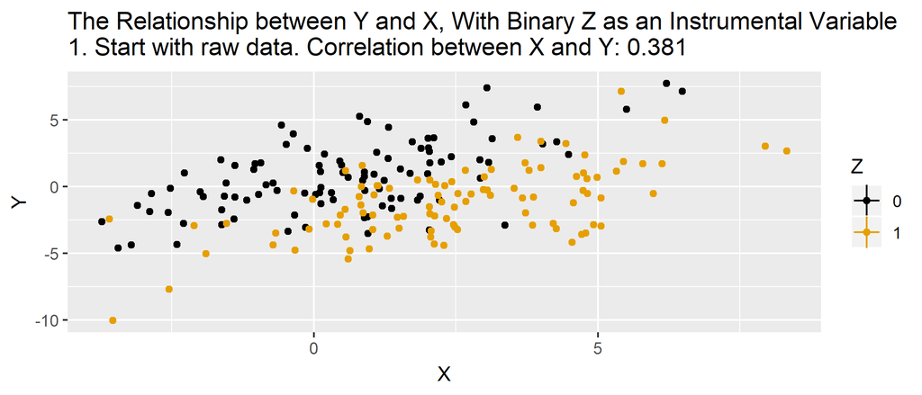

]

# Results with simulated data

Recall that the *true* treatment effect is 5.25 .pull-left[

```
##
## Call:
## lm(formula = y ~ w, data = iv.dat)
##
## Residuals:
##     Min      1Q  Median      3Q     Max
## -3.5306 -0.6654 -0.0089  0.6693  3.8815
##
## Coefficients:
##             Estimate Std. Error t value Pr(>|t|)
## (Intercept)  2.06369    0.01914   107.8   <2e-16 ***
## wTRUE        6.18997    0.02782   222.5   <2e-16 ***
## ---
## Signif. codes:  0 '***' 0.001 '**' 0.01 '*' 0.05 '.' 0.1 ' ' 1
##
## Residual standard error: 0.9823 on 4998 degrees of freedom
## Multiple R-squared:  0.9083, Adjusted R-squared:  0.9083
## F-statistic: 4.949e+04 on 1 and 4998 DF,  p-value: < 2.2e-16
```

]

.pull-right[

```
##
## Call:
## ivreg(formula = y ~ w | z, data = iv.dat)
##
## Residuals:
##      Min       1Q   Median       3Q      Max
## -3.96059 -0.75888  0.03223  0.75392  4.36020
##
## Coefficients:
##             Estimate Std. Error t value Pr(>|t|)
## (Intercept)  2.49372    0.02738   91.08   <2e-16 ***
## wTRUE        5.28120    0.04798  110.07   <2e-16 ***
## ---
## Signif. codes:  0 '***' 0.001 '**' 0.01 '*' 0.05 '.' 0.1 ' ' 1
##
## Residual standard error: 1.082 on 4998 degrees of freedom
## Multiple R-Squared: 0.8887,  Adjusted R-squared: 0.8887
## Wald test: 1.211e+04 on 1 and 4998 DF,  p-value: < 2.2e-16
```

]

# Two-stage equivalence

```r
step1 <- lm(w ~ z, data=iv.dat)
w.hat <- predict(step1)
step2 <- lm(y ~ w.hat, data=iv.dat)
summary(step2)
```

```
##
## Call:
## lm(formula = y ~ w.hat, data = iv.dat)
##
## Residuals:
##     Min      1Q  Median      3Q     Max
## -8.5837 -2.1371 -0.0291  2.0998  8.7810
##
## Coefficients:
##             Estimate Std. Error t value Pr(>|t|)
## (Intercept)  2.49372    0.07013   35.56   <2e-16 ***
## w.hat        5.28120    0.12290   42.97   <2e-16 ***
## ---
## Signif. codes:  0 '***' 0.001 '**' 0.01 '*' 0.05 '.' 0.1 ' ' 1
##
## Residual standard error: 2.772 on 4998 degrees of freedom
## Multiple R-squared:  0.2698, Adjusted R-squared:  0.2696
## F-statistic:  1847 on 1 and 4998 DF,  p-value: < 2.2e-16
```

class: inverse, center, middle name: smoking_data

# Summary stats

We’re interested in cigarette prices and sales, so let’s focus our summaries on those two variables

```r
stargazer(as.data.frame(cig.data %>% select(sales_per_capita, price_cpi, cost_per_pack)), type="html")
```

| Statistic | N | Mean | St. Dev. | Min | Pctl(25) | Pctl(75) | Max |
| --- | --- | --- | --- | --- | --- | --- | --- |
| sales_per_capita | 2,499 | 95.150 | 41.133 | 12.500 | 63.050 | 122.400 | 296.200 |
| price_cpi | 2,499 | 3.396 | 1.641 | 1.307 | 2.088 | 4.520 | 9.651 |
| cost_per_pack | 2,499 | 2.678 | 2.238 | 0.287 | 0.780 | 4.237 | 10.376 |

# Cigarette Sales

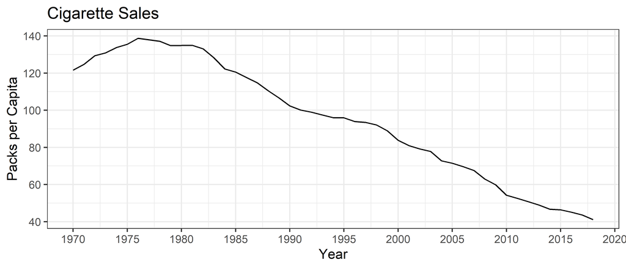

# Cigarette Prices

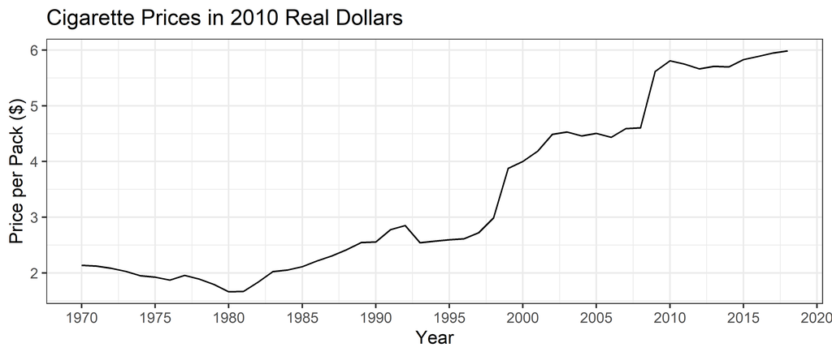

class: inverse, center, middle name: smoking_demand

# Estimating Demand for Cigarettes

# Is this causal?

# Tax as an IV

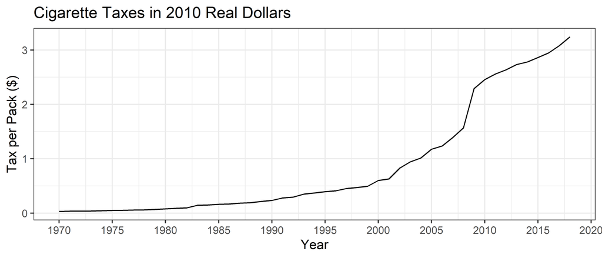

# Two-stage equivalence

```r
step1 <- lm(ln_price ~ total_tax_cpi, data=cig.data)
pricehat <- predict(step1)
step2 <- lm(ln_sales ~ pricehat, data=cig.data)
summary(step2)
```

```
##
## Call:
## lm(formula = ln_sales ~ pricehat, data = cig.data)
##
## Residuals:
##      Min       1Q   Median       3Q      Max
## -0.93630 -0.14892  0.01832  0.14572  0.98954
##
## Coefficients:
##              Estimate Std. Error t value Pr(>|t|)
## (Intercept)  4.767051   0.007154  666.36   <2e-16 ***
## pricehat    -0.552826   0.007504  -73.67   <2e-16 ***
## ---
## Signif. codes:  0 '***' 0.001 '**' 0.01 '*' 0.05 '.' 0.1 ' ' 1
##
## Residual standard error: 0.2831 on 2497 degrees of freedom
## Multiple R-squared:  0.6849, Adjusted R-squared:  0.6848
## F-statistic:  5428 on 1 and 2497 DF,  p-value: < 2.2e-16
```

# Test the IV

[output not shown]

# Some other IV issues

1. IV estimators are biased. Performance in finite samples is questionable.
2. IV estimators provide an estimate of a Local Average Treatment Effect (LATE), which is only the same as the ATT under some conditions or assumptions.
3. What about lots of instruments? The finite sample problem is more important and we may try other things (JIVE).

–  
The National Bureau of Economic Researh (NBER) has a great resource [here](https://www.nber.org/econometrics_minicourse_2018/2018si_methods.pdf) for understanding instruments in practice.